# Practical Machine Learning Course Project

Morris Sta

25 August 2016

## Load the data and get a first idea of it

First, read in the training data and split it into training and testing sets. Also set seed for reproducibility.

```r
library(caret)
set.seed(76)
dataActivity <- read.csv("pml-training.csv")
trainIndex <- createDataPartition(dataActivity$classe, p=0.8, list=FALSE)
training <- dataActivity[trainIndex,]
testing <- dataActivity[-trainIndex,]
#head(training) suppressed for layout reasons
#summary(training)
class(training$classe)
```

```
## [1] "factor"
```

## Identify useless variables

There are variables with many observations (more than 20 percent) being “NA”, which isn’t really helpfull for building a prediction model. Because they are irrelevant I don’t want to use first 7 columns either.

```r
n <- length(training[1,])
obs <- length(training[,1])
varnames <- colnames(training[1,])
nas <- 0
omitInd <- 1:7
for(i in 1:n){
  nas <- sum(is.na(training[,i]))
  if(nas>obs*0.2 && varnames[i]!="classes") omitInd <- cbind(omitInd, i)
}
training <- training[, -omitInd]
testing <- testing[,-omitInd]
```

There are variables with very low variability. I use the nearZeroVar()-function (caret-package) to find them and throw out another 58 variables.

```r
set.seed(123)
nsv <- nearZeroVar(training)
training <- training[,-nsv]
testing <- testing[,-nsv]
```

## Find the most important variables

(idea from machinelearningmastery.com) We still have 52 possible predictors left. Considering scalability, we want to reduce the predictors. Therefore I create a small subset and build a model to determine the most important variables. The method of choice is Random Forest (“rf”) as it is one of the top performing algorithms. Moreover repeated 3-fold-cross-validation is used for a better result.

```r
set.seed(987)
trainSubInd <- createDataPartition(training$classe, p=0.1, list=FALSE)
trainSub <- training[trainSubInd,]
controlSub <- trainControl(method="repeatedcv", number=3, repeats=2)
modSub <- train(classe~., method="rf", trControl = controlSub, data=trainSub)
```

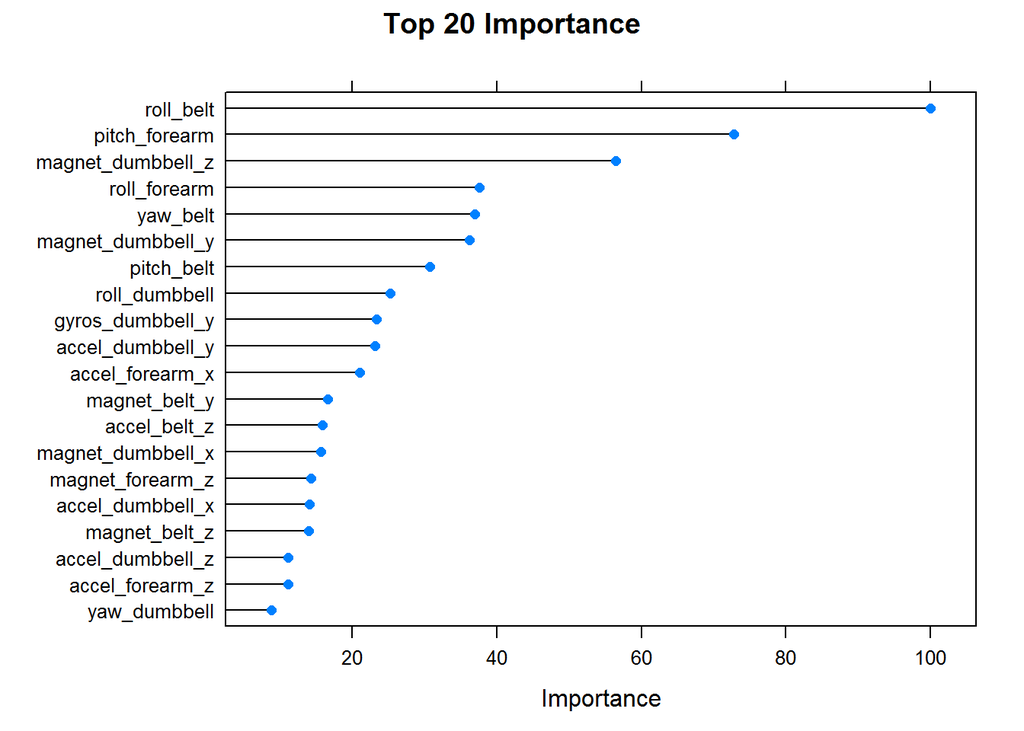

```r
importance <- varImp(modSub)
plot(importance, main= "Top 20 Importance", top=20)
```

## Train the model

We now have an idea of which variables are the best predictors and can build a model based on the top 11 variables (in this case equivalent to 20% quantile as 52*0.2 = 10.4). Again, cross-validation is used.

```r
set.seed(111)
trainData <- training[-trainSubInd,]
topVar <- quantile(importance$importance[,1], 0.8)
select <- c(importance$importance[,1]>topVar, TRUE)
trainData <- trainData[,select]
control <- trainControl(method="cv", number=5)
model <- train(classe~., method="rf", trControl = control, data=trainData )
```

## Evaluate the model

```r
pred <- predict(model, testing)
confMat <- confusionMatrix(pred, testing$classe)
confMat$overall
```

```
##       Accuracy          Kappa  AccuracyLower  AccuracyUpper   AccuracyNull
##      0.9847056      0.9806507      0.9803564      0.9883090      0.2844762
## AccuracyPValue  McnemarPValue
##      0.0000000            NaN
```

```r
confMat$table
```

```
##           Reference
## Prediction    A    B    C    D    E
##          A 1112   11    0    0    0
##          B    1  741    8    0    3
##          C    3    7  674   15    3
##          D    0    0    2  627    6
##          E    0    0    0    1  709
```

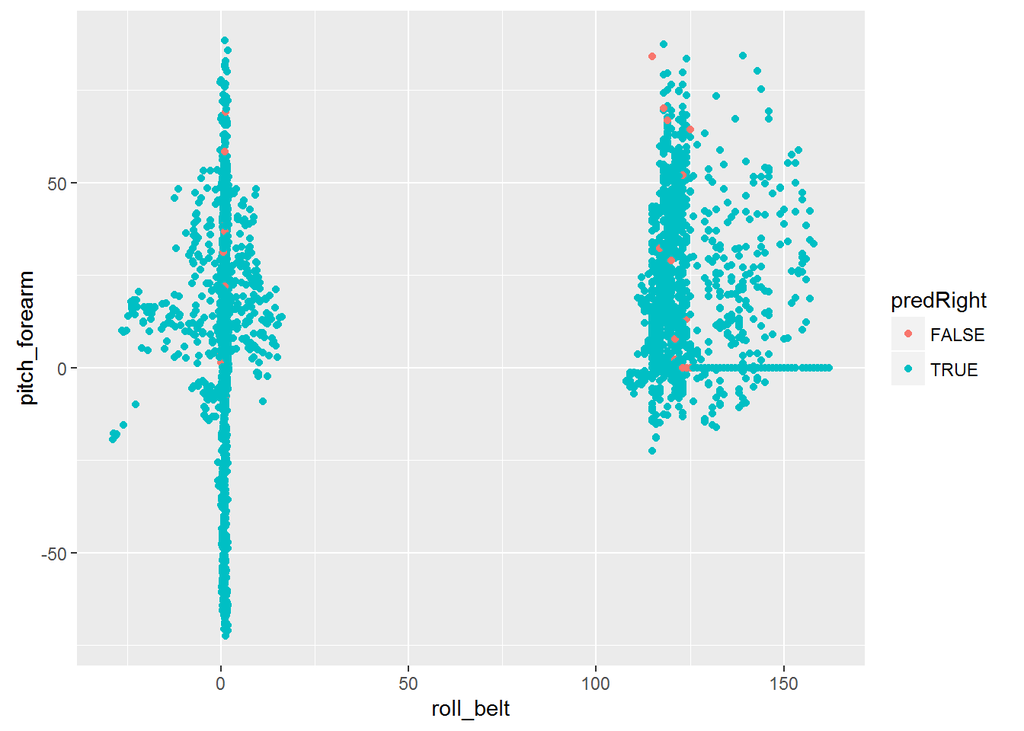

```r
testing$predRight <- pred==testing$classe
qplot(roll_belt, pitch_forearm, color = predRight, data = testing)
```

We get an accuracy of about 98.5%, which makes an out-of-sample-error of about 1.5%.